# Project 2

# Fatalities

From AER v1.2-9 by Achim Zeileis

##### US Traffic Fatalities

US traffic fatalities panel data for the “lower 48” US states (i.e., excluding Alaska and Hawaii), annually for 1982 through 1988.

**Keywords**

datasets

##### Usage

```r
data("Fatalities")
```

##### Details

Traffic fatalities are from the US Department of Transportation Fatal Accident Reporting System. The beer tax is the tax on a case of beer, which is an available measure of state alcohol taxes more generally. The drinking age variable is a factor indicating whether the legal drinking age is 18, 19, or 20. The two binary punishment variables describe the state's minimum sentencing requirements for an initial drunk driving conviction.

Total vehicle miles traveled annually by state was obtained from the Department of Transportation. Personal income was obtained from the US Bureau of Economic Analysis, and the unemployment rate was obtained from the US Bureau of Labor Statistics.

##### Format

A data frame containing 336 observations on 34 variables.

**state**

factor indicating state.

**year**

factor indicating year.

**spirits**

numeric. Spirits consumption.

**unemp**

numeric. Unemployment rate.

**income**

numeric. Per capita personal income in 1987 dollars.

**emppop**

numeric. Employment/population ratio.

**beertax**

numeric. Tax on case of beer.

**baptist**

numeric. Percent of southern baptist.

**mormon**

numeric. Percent of mormon.

**drinkage**

numeric. Minimum legal drinking age.

**dry**

numeric. Percent residing in “dry” countries.

**youngdrivers**

numeric. Percent of drivers aged 15--24.

**miles**

numeric. Average miles per driver.

**breath**

factor. Preliminary breath test law?

**jail**

factor. Mandatory jail sentence?

**service**

factor. Mandatory community service?

**fatal**

numeric. Number of vehicle fatalities.

**nfatal**

numeric. Number of night-time vehicle fatalities.

**sfatal**

numeric. Number of single vehicle fatalities.

**fatal1517**

numeric. Number of vehicle fatalities, 15--17 year olds.

**nfatal1517**

numeric. Number of night-time vehicle fatalities, 15--17 year olds.

**fatal1820**

numeric. Number of vehicle fatalities, 18--20 year olds.

**nfatal1820**

numeric. Number of night-time vehicle fatalities, 18--20 year olds.

**fatal2124**

numeric. Number of vehicle fatalities, 21--24 year olds.

**nfatal2124**

numeric. Number of night-time vehicle fatalities, 21--24 year olds.

**afatal**

numeric. Number of alcohol-involved vehicle fatalities.

**pop**

numeric. Population.

**pop1517**

numeric. Population, 15--17 year olds.

**pop1820**

numeric. Population, 18--20 year olds.

**pop2124**

numeric. Population, 21--24 year olds.

**milestot**

numeric. Total vehicle miles (millions).

**unempus**

numeric. US unemployment rate.

**emppopus**

numeric. US employment/population ratio.

**gsp**

numeric. GSP rate of change.

##### References

Ruhm, C. J. (1996). Alcohol Policies and Highway Vehicle Fatalities. *Journal of Health Economics*, **15**, 435--454.

Stock, J. H. and Watson, M. W. (2007). *Introduction to Econometrics*, 2nd ed. Boston: Addison Wesley.

##### See Also

`StockWatson2007`

##### Examples

```r
# NOT RUN {
## data from Stock and Watson (2007)
data("Fatalities", package = "AER")
## add fatality rate (number of traffic deaths
## per 10,000 people living in that state in that year)
Fatalities$frate <- with(Fatalities, fatal/pop * 10000)
## add discretized version of minimum legal drinking age
Fatalities$drinkagec <- cut(Fatalities$drinkage,
  breaks = 18:22, include.lowest = TRUE, right = FALSE)
Fatalities$drinkagec <- relevel(Fatalities$drinkagec, ref = 4)
## any punishment?
Fatalities$punish <- with(Fatalities,
  factor(jail == "yes" | service == "yes", labels = c("no", "yes")))
## plm package
library("plm")

## for comparability with Stata we use HC1 below
## p. 351, Eq. (10.2)
f1982 <- subset(Fatalities, year == "1982")
fm_1982 <- lm(frate ~ beertax, data = f1982)
coeftest(fm_1982, vcov = vcovHC(fm_1982, type = "HC1"))

## p. 353, Eq. (10.3)
f1988 <- subset(Fatalities, year == "1988")
fm_1988 <- lm(frate ~ beertax, data = f1988)
coeftest(fm_1988, vcov = vcovHC(fm_1988, type = "HC1"))

## pp. 355, Eq. (10.8)
fm_diff <- lm(I(f1988$frate - f1982$frate) ~ I(f1988$beertax - f1982$beertax))
coeftest(fm_diff, vcov = vcovHC(fm_diff, type = "HC1"))

## pp. 360, Eq. (10.15)
##   (1) via formula
fm_sfe <- lm(frate ~ beertax + state - 1, data = Fatalities)
##   (2) by hand
fat <- with(Fatalities,
  data.frame(frates = frate - ave(frate, state),
  beertaxs = beertax - ave(beertax, state)))
fm_sfe2 <- lm(frates ~ beertaxs - 1, data = fat)
##   (3) via plm()
fm_sfe3 <- plm(frate ~ beertax, data = Fatalities,
  index = c("state", "year"), model = "within")

coeftest(fm_sfe, vcov = vcovHC(fm_sfe, type = "HC1"))[1,]
## uses different df in sd and p-value
coeftest(fm_sfe2, vcov = vcovHC(fm_sfe2, type = "HC1"))[1,]
## uses different df in p-value
coeftest(fm_sfe3, vcov = vcovHC(fm_sfe3, type = "HC1", method = "white1"))[1,]


## pp. 363, Eq. (10.21)
## via lm()
fm_stfe <- lm(frate ~ beertax + state + year - 1, data = Fatalities)
coeftest(fm_stfe, vcov = vcovHC(fm_stfe, type = "HC1"))[1,]
## via plm()
fm_stfe2 <- plm(frate ~ beertax, data = Fatalities,
  index = c("state", "year"), model = "within", effect = "twoways")
coeftest(fm_stfe2, vcov = vcovHC) ## different


## p. 368, Table 10.1, numbers refer to cols.
fm1 <- plm(frate ~ beertax, data = Fatalities, index = c("state", "year"), model = "pooling")
fm2 <- plm(frate ~ beertax, data = Fatalities, index = c("state", "year"), model = "within")
fm3 <- plm(frate ~ beertax, data = Fatalities, index = c("state", "year"), model = "within",
  effect = "twoways")
fm4 <- plm(frate ~ beertax + drinkagec + jail + service + miles + unemp + log(income),
  data = Fatalities, index = c("state", "year"), model = "within", effect = "twoways")
fm5 <- plm(frate ~ beertax + drinkagec + jail + service + miles,
  data = Fatalities, index = c("state", "year"), model = "within", effect = "twoways")
fm6 <- plm(frate ~ beertax + drinkage + punish + miles + unemp + log(income),
  data = Fatalities, index = c("state", "year"), model = "within", effect = "twoways")
fm7 <- plm(frate ~ beertax + drinkagec + jail + service + miles + unemp + log(income),
  data = Fatalities, index = c("state", "year"), model = "within", effect = "twoways")
## summaries not too close, s.e.s generally too small
coeftest(fm1, vcov = vcovHC)
coeftest(fm2, vcov = vcovHC)
coeftest(fm3, vcov = vcovHC)
coeftest(fm4, vcov = vcovHC)
coeftest(fm5, vcov = vcovHC)
coeftest(fm6, vcov = vcovHC)
coeftest(fm7, vcov = vcovHC)

## TODO: Testing exclusion restrictions

# }
```

- Explanation of variables found here: Fatalities

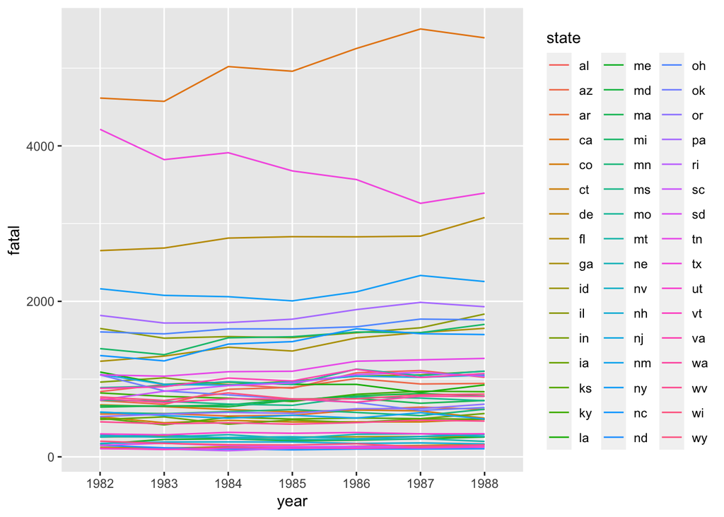

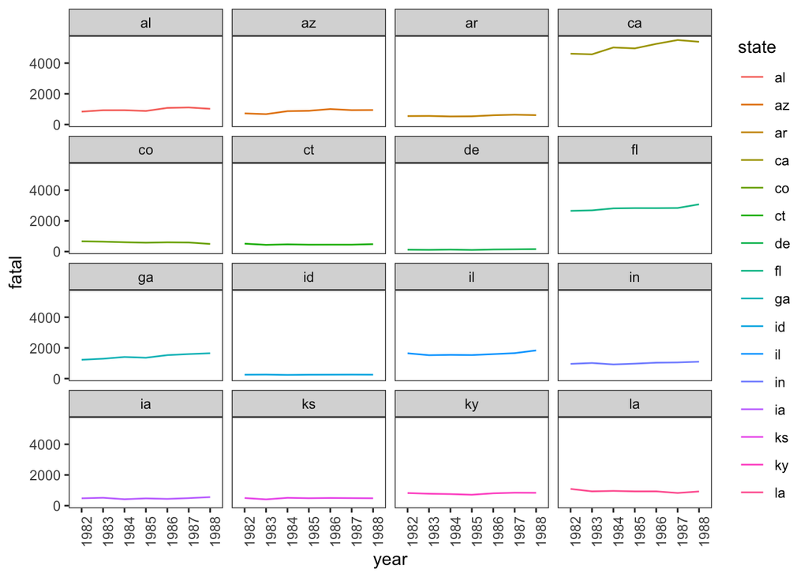

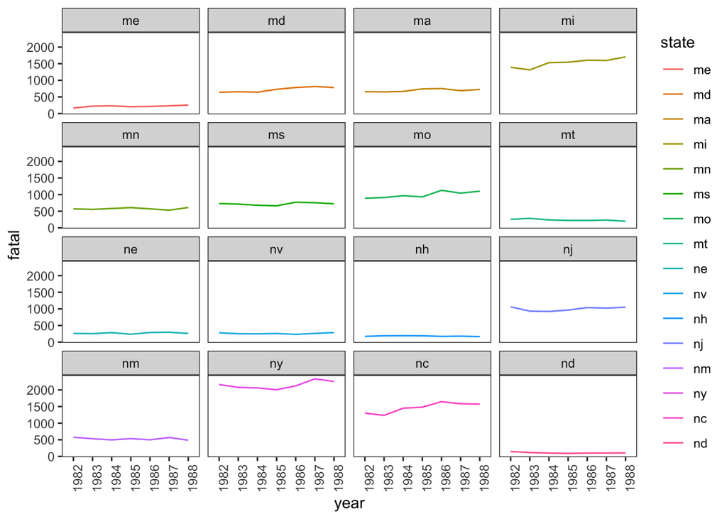

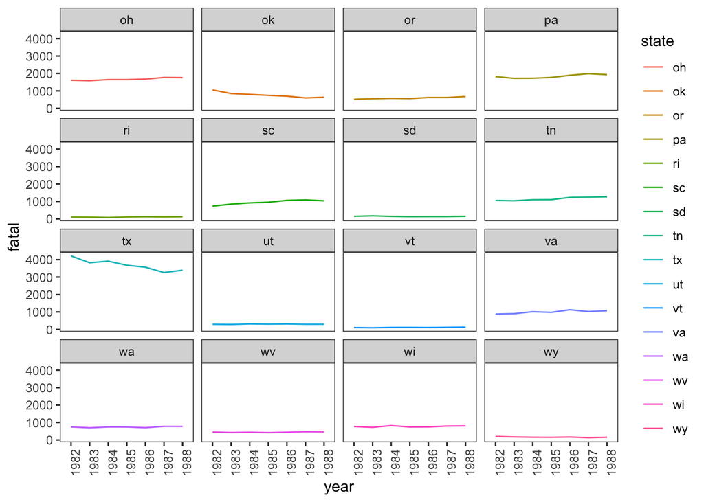

We first make the time series plots for the number of fatalities of each state from 1982 to 1988. From the plots above, we can find that the numbers of fatalities vary a lot, making it difficult to identify if there is any pattern. Therefore, we try to use the ratio of the number of fatalities over the population of the state, and make the time series plots for each state again. From the plots below, we can observe that there are certain states show similar patterns. Therefore, we want to understand what the factors in this data set affect the change of the number of fatalities are.

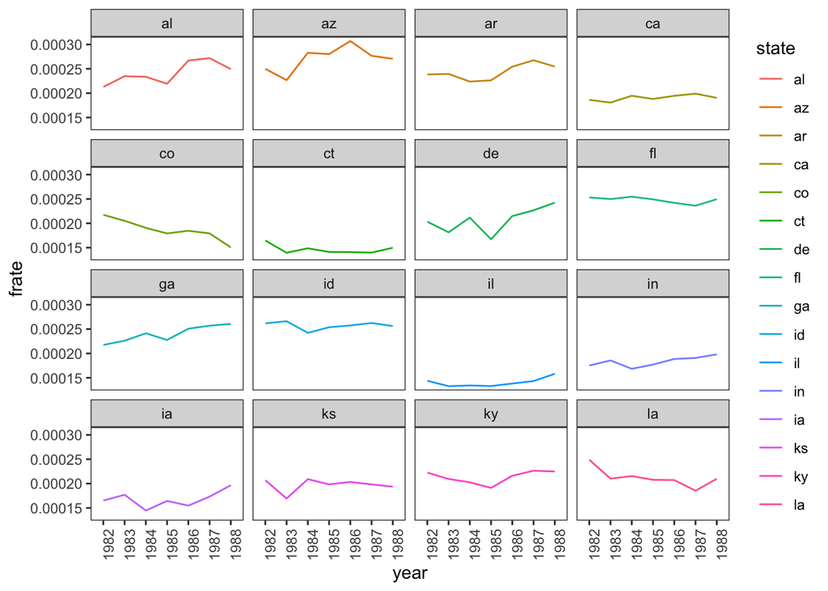

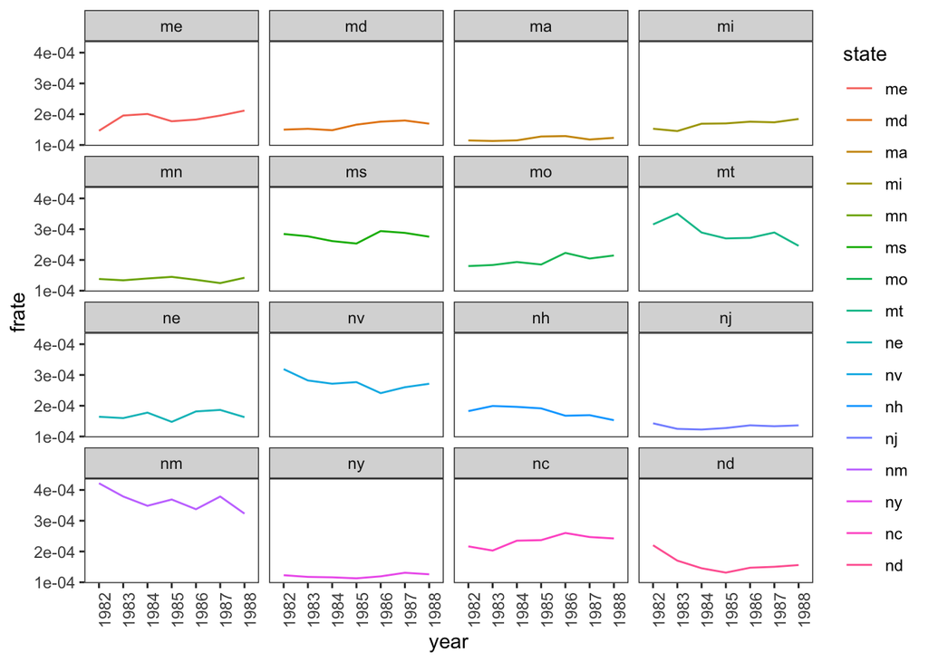

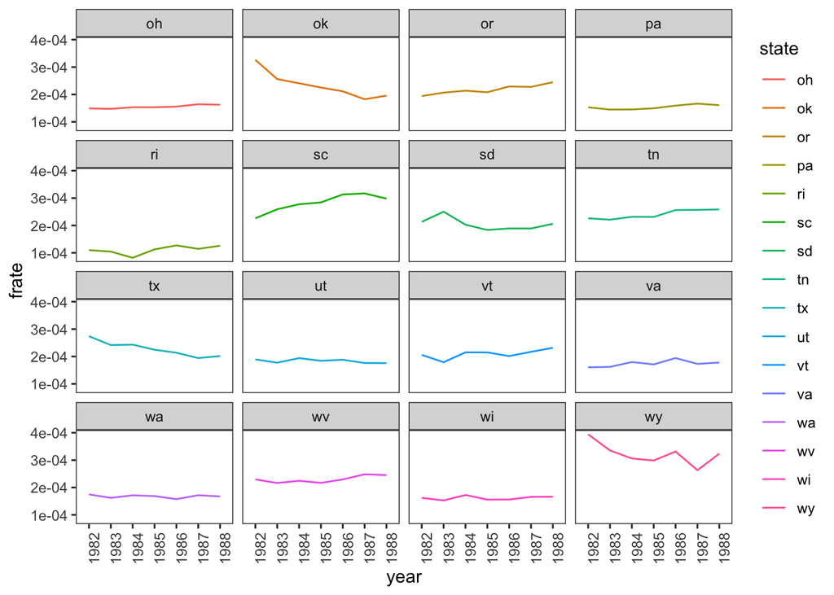

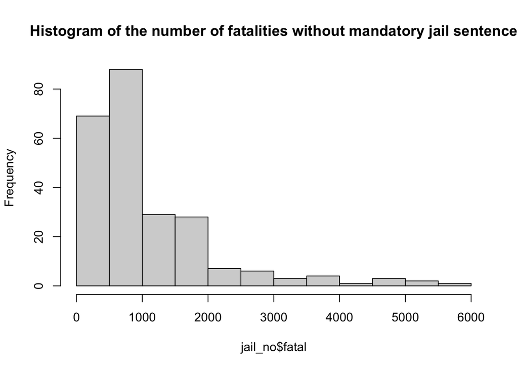

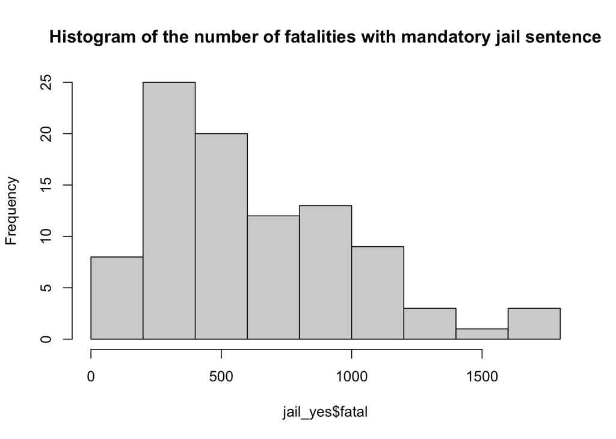

[1] 1034.427 [1] 610.0426

We are interested to know if the mandatory jail sentence for the traffic fatalities has any relationship with the number of fatalities. From the histogram of the number of fatalities with mandatory jail sentence and that without, we find that the the number of fatalities with mandatory jail sentence is smaller than that without jail sentence.

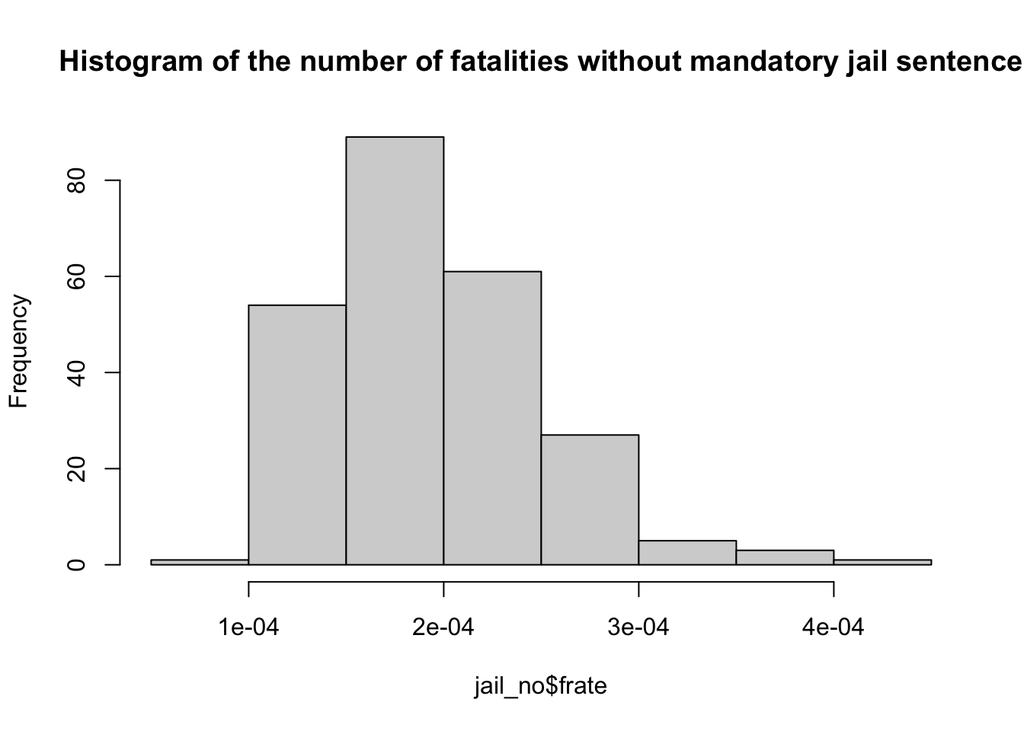

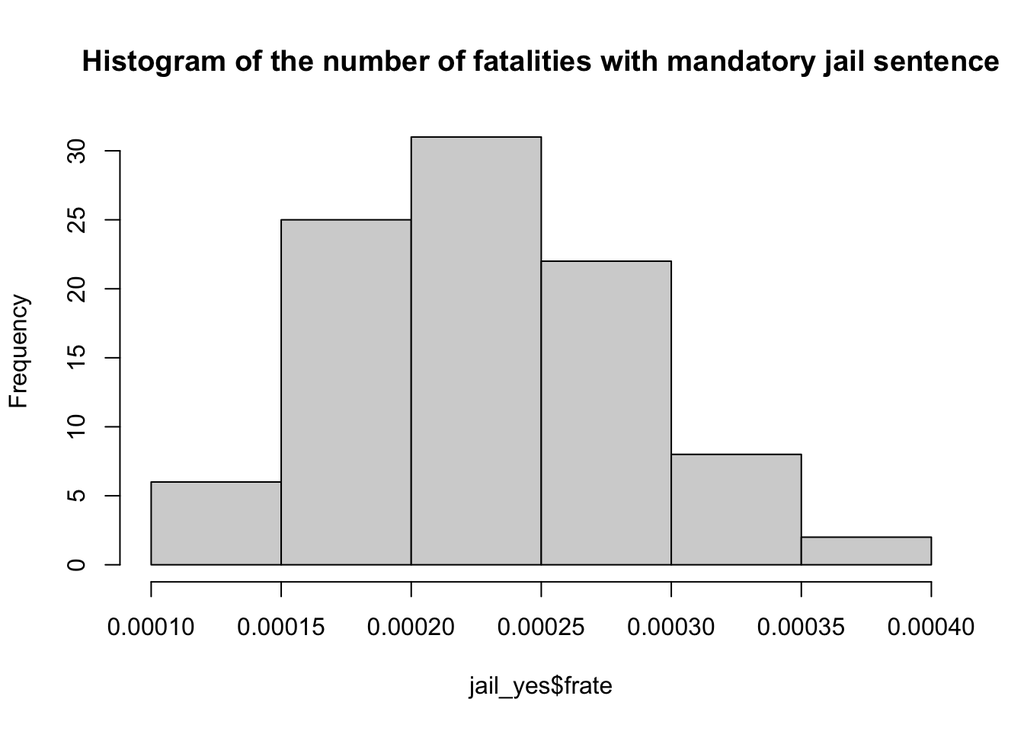

However, because the populations of different states vary, we also use the ratio of the total number of fatalities over the population of the state to plot histograms again, and we find that the ratio in the histogram of mandatory jail sentence is larger than that that in the histogram without jail sentence. So, the population of each state may be affecting our analysis.

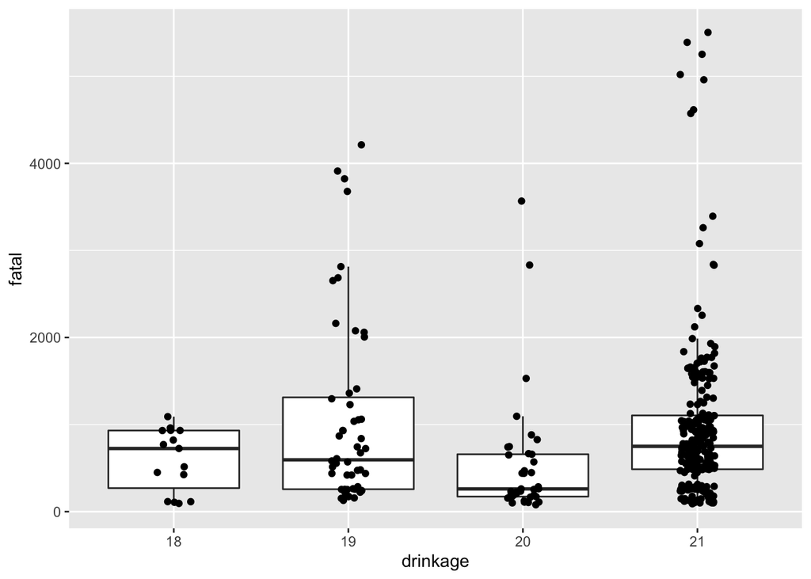

We also investigate the relationship between the number of fatalities and the minimum legal drinking age. Since the minimum drinking ages are not necessarily whole numbers, we round them to the nearest integer. From the twp-way box plot above, we can observe that the states with legal minimum drinking ages 18 and 21 are associated with the largest average number of fatalities, and that the states with minimum legal drinking age 20 seems has the smallest average number of fatalities. We also noticed that the data points of minimum drinking age 21 disperse widely.

```
## 1 observations missing `jail` have been removed. To include these observations, use `forcats::fct_explicit_na()` on `jail` column before passing to `tbl_summary()`.
```

| **Characteristic** | **no**, N = 241<sup>1</sup> | **yes**, N = 94<sup>1</sup> | **p-value**<sup>2</sup> |
| --- | --- | --- | --- |
| unemp | 6.900000 (5.300000, 8.700000) | 7.650000 (6.025000, 9.400000) | 0.019 |
| frate | 0.000194 (0.000055, 0.000186, 0.000073) | 0.000229 (0.000055, 0.000225, 0.000085) | <0.001 |

<sup>*1*</sup> Median (IQR); Mean (SD, Median, IQR) <sup>*2*</sup> Wilcoxon rank sum test

| **Characteristic** | **18**, N = 15<sup>1</sup> | **19**, N = 52<sup>1</sup> | **20**, N = 37<sup>1</sup> | **21**, N = 232<sup>1</sup> | **p-value**<sup>2</sup> |
| --- | --- | --- | --- | --- | --- |
| frate | 0.000200 (0.000027, 0.000208, 0.000039) | 0.000227 (0.000066, 0.000234, 0.000099) | 0.000181 (0.000053, 0.000182, 0.000057) | 0.000203 (0.000055, 0.000192, 0.000075) | 0.004 |

<sup>*1*</sup> Mean (SD, Median, IQR) <sup>*2*</sup> Kruskal-Wallis rank sum test

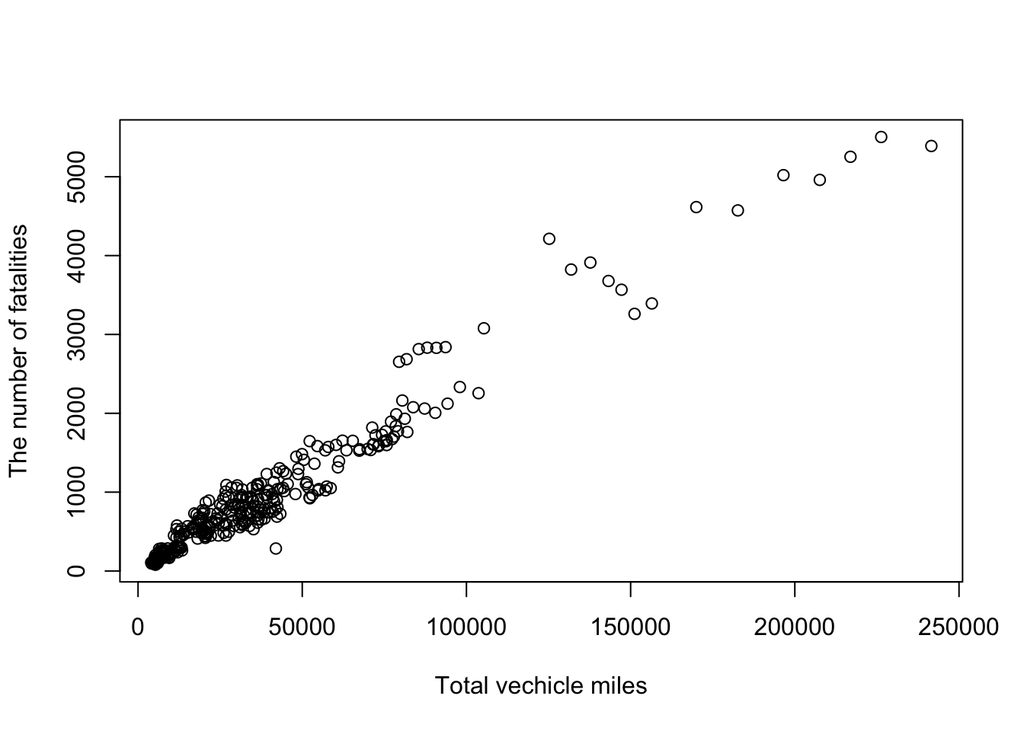

From the plot above, we can find that the there is a linear relationship between the number of fatalities and total vehicle miles.

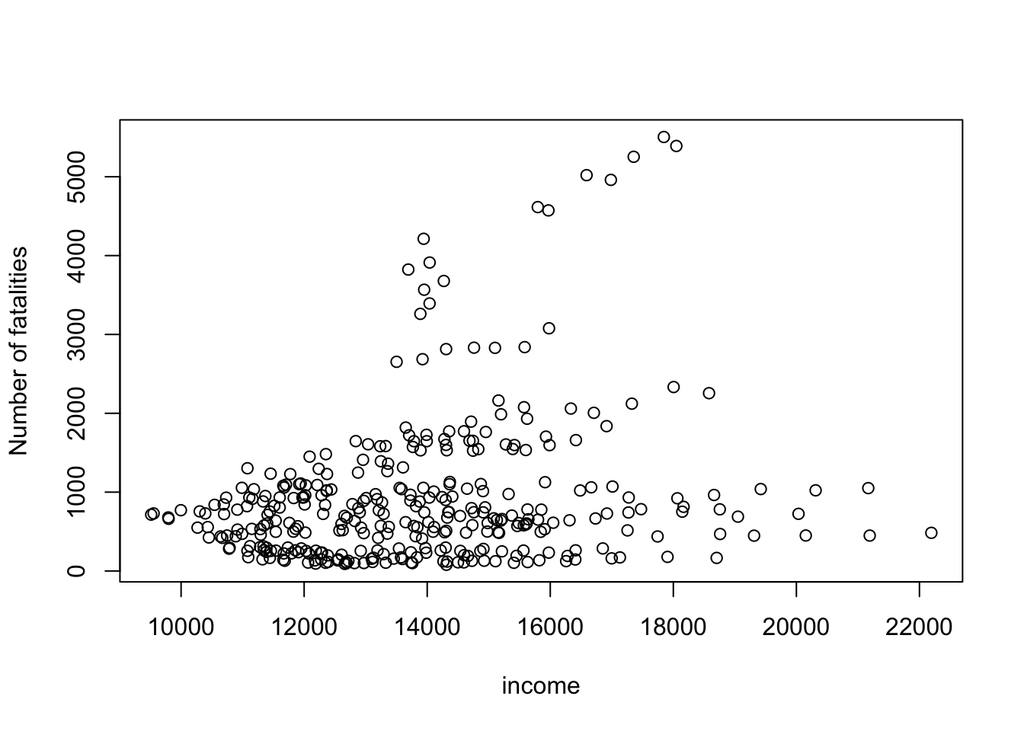

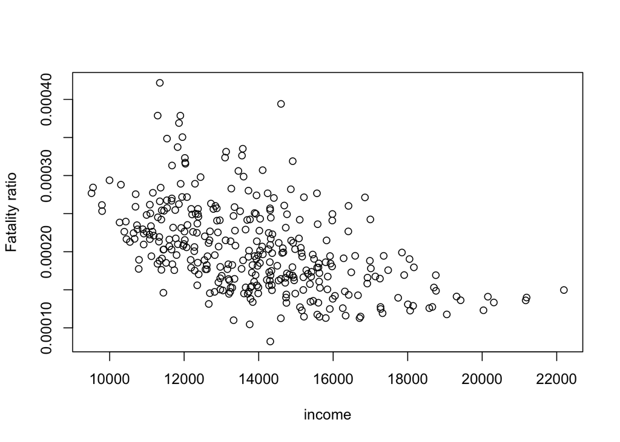

| **Characteristic** | **1st**, N = 84<sup>1</sup> | **2nd**, N = 84<sup>1</sup> | **3rd**, N = 84<sup>1</sup> | **4th**, N = 84<sup>1</sup> | **p-value**<sup>2</sup> |
| --- | --- | --- | --- | --- | --- |
| frate | 0.000246 (0.000052, 0.000233, 0.000058) | 0.000209 (0.000053, 0.000204, 0.000080) | 0.000196 (0.000050, 0.000192, 0.000057) | 0.000165 (0.000040, 0.000160, 0.000050) | <0.001 |

<sup>*1*</sup> Mean (SD, Median, IQR) <sup>*2*</sup> Kruskal-Wallis rank sum test

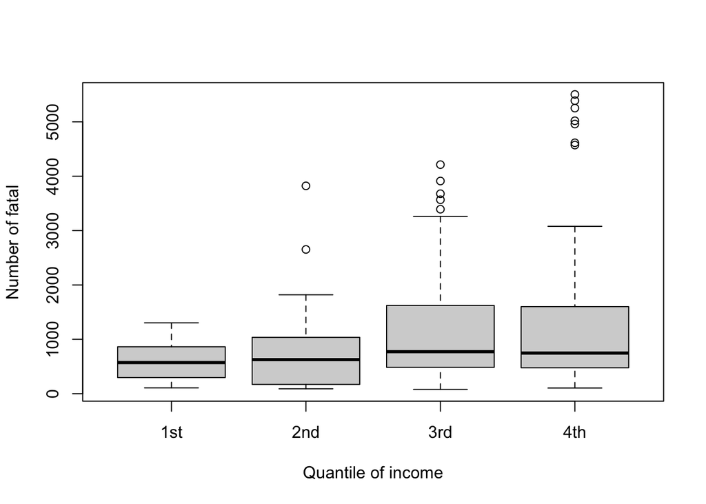

We use quantiles to reclassify income, and plot the two-way box plot between income and the number of fatalities. We can observe that the third and fourth quantiles of incomes have higher average numbers of fatalities.

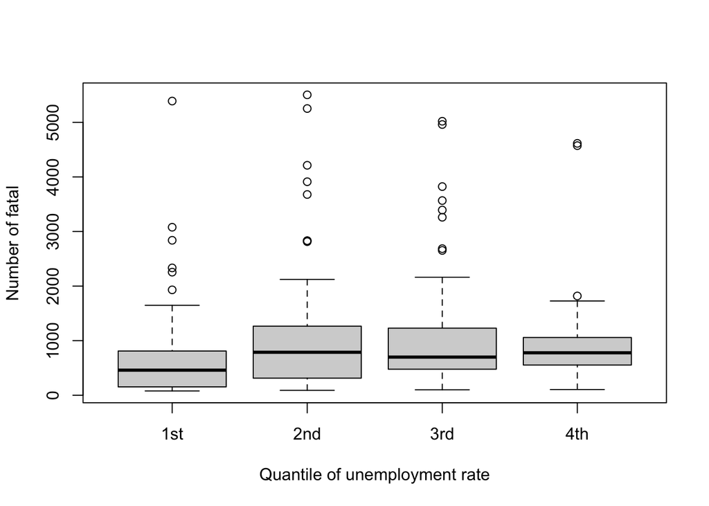

We use quantiles to reclassify unemployment rate, and plot two-way box plot between unemployment rate and the number of fatalities, we can observe that the third and the first quantiles have the lowest average numbers of fatalities.